# cbbe5251-8f67-41dd-8239-958cc0a93a3b

**Review**

Hello Mohamad!

I'm happy to review your project today.

You can find my comments in colored markdown cells:

If everything is done successfully.

If I have some (optional) suggestions, or questions to think about, or general comments.

If a section requires some corrections. Work can't be accepted with red comments.

Please don't remove my comments, as it will make further review iterations much harder for me.

Feel free to reply to my comments or ask questions using the following template:

For your comments and questions.

First of all, thank you for turning in the project! You did a great job overall, but there are some small problems that need to be fixed before the project will be accepted. Let me know if you have any questions!

# Integrated Project: Zyfra Prototype Machine Learning Model for Gold Recovery.

## In this project we will prepare a prototype of a Machine Learning model for Zyfra. The model will help them predict the amount of gold recovered from gold ore for the sake of eliminating unfeasible parameters and boosting production.

```python
# 1.1

# Import Libraries

import pandas as pd
import numpy as np
from sklearn.metrics import mean_absolute_error
import matplotlib.pyplot as plt
import seaborn as sns
from scipy import stats
from sklearn.model_selection import cross_val_score, train_test_split, KFold
from sklearn.linear_model import LinearRegression
from sklearn.ensemble import RandomForestRegressor, GradientBoostingRegressor
from sklearn.tree import DecisionTreeRegressor
from sklearn.preprocessing import StandardScaler
from sklearn.impute import SimpleImputer
from sklearn.svm import SVR
from xgboost import XGBRegressor
from sklearn.model_selection import GridSearchCV
from sklearn.metrics import make_scorer
from sklearn.model_selection import train_test_split
from sklearn.model_selection import cross_val_predict, RandomizedSearchCV
from scipy.stats import randint
from sklearn.decomposition import PCA
from sklearn.preprocessing import MinMaxScaler, RobustScaler
```

### Libraries imported

```python
# Load datasets

train_data = pd.read_csv('/datasets/gold_recovery_train.csv')
test_data = pd.read_csv('/datasets/gold_recovery_test.csv')
full_data = pd.read_csv('/datasets/gold_recovery_full.csv')
```

```python
# Working Code

train_data.info()
```

```
<class 'pandas.core.frame.DataFrame'>
RangeIndex: 16860 entries, 0 to 16859
Data columns (total 87 columns):
 #   Column                                              Non-Null Count  Dtype
---  ------                                              --------------  -----
 0   date                                                16860 non-null  object
 1   final.output.concentrate_ag                         16788 non-null  float64
 2   final.output.concentrate_pb                         16788 non-null  float64
 3   final.output.concentrate_sol                        16490 non-null  float64
 4   final.output.concentrate_au                         16789 non-null  float64
 5   final.output.recovery                               15339 non-null  float64
 6   final.output.tail_ag                                16794 non-null  float64
 7   final.output.tail_pb                                16677 non-null  float64
 8   final.output.tail_sol                               16715 non-null  float64
 9   final.output.tail_au                                16794 non-null  float64
```

[output cut: 79 more lines]

### 87 columns in the Train dataset.

```python
# Working Code

test_data.info()
```

```
<class 'pandas.core.frame.DataFrame'>
RangeIndex: 5856 entries, 0 to 5855
Data columns (total 53 columns):
 #   Column                                      Non-Null Count  Dtype
---  ------                                      --------------  -----
 0   date                                        5856 non-null   object
 1   primary_cleaner.input.sulfate               5554 non-null   float64
 2   primary_cleaner.input.depressant            5572 non-null   float64
 3   primary_cleaner.input.feed_size             5856 non-null   float64
 4   primary_cleaner.input.xanthate              5690 non-null   float64
 5   primary_cleaner.state.floatbank8_a_air      5840 non-null   float64
 6   primary_cleaner.state.floatbank8_a_level    5840 non-null   float64
 7   primary_cleaner.state.floatbank8_b_air      5840 non-null   float64
 8   primary_cleaner.state.floatbank8_b_level    5840 non-null   float64
 9   primary_cleaner.state.floatbank8_c_air      5840 non-null   float64
```

[output cut: 45 more lines]

### 53 columns in the Test dataset.

```python
# Working Code

full_data.info()
```

```
<class 'pandas.core.frame.DataFrame'>
RangeIndex: 22716 entries, 0 to 22715
Data columns (total 87 columns):
 #   Column                                              Non-Null Count  Dtype
---  ------                                              --------------  -----
 0   date                                                22716 non-null  object
 1   final.output.concentrate_ag                         22627 non-null  float64
 2   final.output.concentrate_pb                         22629 non-null  float64
 3   final.output.concentrate_sol                        22331 non-null  float64
 4   final.output.concentrate_au                         22630 non-null  float64
 5   final.output.recovery                               20753 non-null  float64
 6   final.output.tail_ag                                22633 non-null  float64
 7   final.output.tail_pb                                22516 non-null  float64
 8   final.output.tail_sol                               22445 non-null  float64
 9   final.output.tail_au                                22635 non-null  float64
```

[output cut: 79 more lines]

### 87 columns in the Full dataset.

```python
# Working code

train_data.describe()
```

|  | final.output.concentrate_ag | final.output.concentrate_pb | final.output.concentrate_sol | final.output.concentrate_au | final.output.recovery | final.output.tail_ag | final.output.tail_pb | final.output.tail_sol | final.output.tail_au | primary_cleaner.input.sulfate | ... | secondary_cleaner.state.floatbank4_a_air | secondary_cleaner.state.floatbank4_a_level | secondary_cleaner.state.floatbank4_b_air | secondary_cleaner.state.floatbank4_b_level | secondary_cleaner.state.floatbank5_a_air | secondary_cleaner.state.floatbank5_a_level | secondary_cleaner.state.floatbank5_b_air | secondary_cleaner.state.floatbank5_b_level | secondary_cleaner.state.floatbank6_a_air | secondary_cleaner.state.floatbank6_a_level |
| --- | --- | --- | --- | --- | --- | --- | --- | --- | --- | --- | --- | --- | --- | --- | --- | --- | --- | --- | --- | --- | --- |
| count | 16788.000000 | 16788.000000 | 16490.000000 | 16789.000000 | 15339.000000 | 16794.000000 | 16677.000000 | 16715.000000 | 16794.000000 | 15553.000000 | ... | 16731.000000 | 16747.000000 | 16768.000000 | 16767.000000 | 16775.000000 | 16775.000000 | 16775.000000 | 16776.000000 | 16757.000000 | 16775.000000 |
| mean | 4.716907 | 9.113559 | 8.301123 | 39.467217 | 67.213166 | 8.757048 | 2.360327 | 9.303932 | 2.687512 | 129.479789 | ... | 19.101874 | -494.164481 | 14.778164 | -476.600082 | 15.779488 | -500.230146 | 12.377241 | -498.956257 | 18.429208 | -521.801826 |
| std | 2.096718 | 3.389495 | 3.825760 | 13.917227 | 11.960446 | 3.634103 | 1.215576 | 4.263208 | 1.272757 | 45.386931 | ... | 6.883163 | 84.803334 | 5.999149 | 89.381172 | 6.834703 | 76.983542 | 6.219989 | 82.146207 | 6.958294 | 77.170888 |
| min | 0.000000 | 0.000000 | 0.000000 | 0.000000 | 0.000000 | 0.000000 | 0.000000 | 0.000000 | 0.000000 | 0.000003 | ... | 0.000000 | -799.920713 | 0.000000 | -800.021781 | -0.423260 | -799.741097 | 0.427084 | -800.258209 | 0.024270 | -810.473526 |
| 25% | 3.971262 | 8.825748 | 6.939185 | 42.055722 | 62.625685 | 7.610544 | 1.641604 | 7.870275 | 2.172953 | 103.064021 | ... | 14.508299 | -500.837689 | 10.741388 | -500.269182 | 10.977713 | -500.530594 | 8.925586 | -500.147603 | 13.977626 | -501.080595 |
| 50% | 4.869346 | 10.065316 | 8.557228 | 44.498874 | 67.644601 | 9.220393 | 2.453690 | 10.021968 | 2.781132 | 131.783108 | ... | 19.986958 | -499.778379 | 14.943933 | -499.593286 | 15.998340 | -499.784231 | 11.092839 | -499.933330 | 18.034960 | -500.109898 |
| 75% | 5.821176 | 11.054809 | 10.289741 | 45.976222 | 72.824595 | 10.971110 | 3.192404 | 11.648573 | 3.416936 | 159.539839 | ... | 24.983961 | -494.648754 | 20.023751 | -400.137948 | 20.000701 | -496.531781 | 15.979467 | -498.418000 | 24.984992 | -499.565540 |
| max | 16.001945 | 17.031899 | 18.124851 | 53.611374 | 100.000000 | 19.552149 | 6.086532 | 22.317730 | 9.789625 | 251.999948 | ... | 60.000000 | -127.692333 | 28.003828 | -71.472472 | 63.116298 | -275.073125 | 39.846228 | -120.190931 | 54.876806 | -39.784927 |

8 rows × 86 columns

```python
# Working Code

test_data.describe()
```

|  | primary_cleaner.input.sulfate | primary_cleaner.input.depressant | primary_cleaner.input.feed_size | primary_cleaner.input.xanthate | primary_cleaner.state.floatbank8_a_air | primary_cleaner.state.floatbank8_a_level | primary_cleaner.state.floatbank8_b_air | primary_cleaner.state.floatbank8_b_level | primary_cleaner.state.floatbank8_c_air | primary_cleaner.state.floatbank8_c_level | ... | secondary_cleaner.state.floatbank4_a_air | secondary_cleaner.state.floatbank4_a_level | secondary_cleaner.state.floatbank4_b_air | secondary_cleaner.state.floatbank4_b_level | secondary_cleaner.state.floatbank5_a_air | secondary_cleaner.state.floatbank5_a_level | secondary_cleaner.state.floatbank5_b_air | secondary_cleaner.state.floatbank5_b_level | secondary_cleaner.state.floatbank6_a_air | secondary_cleaner.state.floatbank6_a_level |
| --- | --- | --- | --- | --- | --- | --- | --- | --- | --- | --- | --- | --- | --- | --- | --- | --- | --- | --- | --- | --- | --- |
| count | 5554.000000 | 5572.000000 | 5856.000000 | 5690.000000 | 5840.000000 | 5840.000000 | 5840.000000 | 5840.000000 | 5840.000000 | 5840.000000 | ... | 5840.000000 | 5840.000000 | 5840.000000 | 5840.000000 | 5840.000000 | 5840.000000 | 5840.000000 | 5840.000000 | 5840.000000 | 5840.000000 |
| mean | 170.515243 | 8.482873 | 7.264651 | 1.321420 | 1481.990241 | -509.057796 | 1486.908670 | -511.743956 | 1468.495216 | -509.741212 | ... | 15.636031 | -516.266074 | 13.145702 | -476.338907 | 12.308967 | -512.208126 | 9.470986 | -505.017827 | 16.678722 | -512.351694 |
| std | 49.608602 | 3.353105 | 0.611526 | 0.693246 | 310.453166 | 61.339256 | 313.224286 | 67.139074 | 309.980748 | 62.671873 | ... | 4.660835 | 62.756748 | 4.304086 | 105.549424 | 3.762827 | 58.864651 | 3.312471 | 68.785898 | 5.404514 | 69.919839 |
| min | 0.000103 | 0.000031 | 5.650000 | 0.000003 | 0.000000 | -799.773788 | 0.000000 | -800.029078 | 0.000000 | -799.995127 | ... | 0.000000 | -799.798523 | 0.000000 | -800.836914 | -0.223393 | -799.661076 | 0.528083 | -800.220337 | -0.079426 | -809.859706 |
| 25% | 143.340022 | 6.411500 | 6.885625 | 0.888769 | 1497.190681 | -500.455211 | 1497.150234 | -500.936639 | 1437.050321 | -501.300441 | ... | 12.057838 | -501.054741 | 11.880119 | -500.419113 | 10.123459 | -500.879383 | 7.991208 | -500.223089 | 13.012422 | -500.833821 |
| 50% | 176.103893 | 8.023252 | 7.259333 | 1.183362 | 1554.659783 | -499.997402 | 1553.268084 | -500.066588 | 1546.160672 | -500.079537 | ... | 17.001867 | -500.160145 | 14.952102 | -499.644328 | 12.062877 | -500.047621 | 9.980774 | -500.001338 | 16.007242 | -500.041085 |
| 75% | 207.240761 | 10.017725 | 7.650000 | 1.763797 | 1601.681656 | -499.575313 | 1601.784707 | -499.323361 | 1600.785573 | -499.009545 | ... | 18.030985 | -499.441529 | 15.940011 | -401.523664 | 15.017881 | -499.297033 | 11.992176 | -499.722835 | 21.009076 | -499.395621 |
| max | 274.409626 | 40.024582 | 15.500000 | 5.433169 | 2212.432090 | -57.195404 | 1975.147923 | -142.527229 | 1715.053773 | -150.937035 | ... | 30.051797 | -401.565212 | 31.269706 | -6.506986 | 25.258848 | -244.483566 | 14.090194 | -126.463446 | 26.705889 | -29.093593 |

8 rows × 52 columns

```python
# Working Code

full_data.describe()
```

|  | final.output.concentrate_ag | final.output.concentrate_pb | final.output.concentrate_sol | final.output.concentrate_au | final.output.recovery | final.output.tail_ag | final.output.tail_pb | final.output.tail_sol | final.output.tail_au | primary_cleaner.input.sulfate | ... | secondary_cleaner.state.floatbank4_a_air | secondary_cleaner.state.floatbank4_a_level | secondary_cleaner.state.floatbank4_b_air | secondary_cleaner.state.floatbank4_b_level | secondary_cleaner.state.floatbank5_a_air | secondary_cleaner.state.floatbank5_a_level | secondary_cleaner.state.floatbank5_b_air | secondary_cleaner.state.floatbank5_b_level | secondary_cleaner.state.floatbank6_a_air | secondary_cleaner.state.floatbank6_a_level |
| --- | --- | --- | --- | --- | --- | --- | --- | --- | --- | --- | --- | --- | --- | --- | --- | --- | --- | --- | --- | --- | --- |
| count | 22627.000000 | 22629.000000 | 22331.000000 | 22630.000000 | 20753.000000 | 22633.000000 | 22516.000000 | 22445.000000 | 22635.000000 | 21107.000000 | ... | 22571.000000 | 22587.000000 | 22608.000000 | 22607.000000 | 22615.000000 | 22615.000000 | 22615.000000 | 22616.000000 | 22597.000000 | 22615.000000 |
| mean | 4.781559 | 9.095308 | 8.640317 | 40.001172 | 67.447488 | 8.923690 | 2.488252 | 9.523632 | 2.827459 | 140.277672 | ... | 18.205125 | -499.878977 | 14.356474 | -476.532613 | 14.883276 | -503.323288 | 11.626743 | -500.521502 | 17.976810 | -519.361465 |
| std | 2.030128 | 3.230797 | 3.785035 | 13.398062 | 11.616034 | 3.517917 | 1.189407 | 4.079739 | 1.262834 | 49.919004 | ... | 6.560700 | 80.273964 | 5.655791 | 93.822791 | 6.372811 | 72.925589 | 5.757449 | 78.956292 | 6.636203 | 75.477151 |
| min | 0.000000 | 0.000000 | 0.000000 | 0.000000 | 0.000000 | 0.000000 | 0.000000 | 0.000000 | 0.000000 | 0.000003 | ... | 0.000000 | -799.920713 | 0.000000 | -800.836914 | -0.423260 | -799.741097 | 0.427084 | -800.258209 | -0.079426 | -810.473526 |
| 25% | 4.018525 | 8.750171 | 7.116799 | 42.383721 | 63.282393 | 7.684016 | 1.805376 | 8.143576 | 2.303108 | 110.177081 | ... | 14.095940 | -500.896232 | 10.882675 | -500.309169 | 10.941299 | -500.628697 | 8.037533 | -500.167897 | 13.968418 | -500.981671 |
| 50% | 4.953729 | 9.914519 | 8.908792 | 44.653436 | 68.322258 | 9.484369 | 2.653001 | 10.212998 | 2.913794 | 141.330501 | ... | 18.007326 | -499.917108 | 14.947646 | -499.612292 | 14.859117 | -499.865158 | 10.989756 | -499.951980 | 18.004215 | -500.095463 |
| 75% | 5.862593 | 10.929839 | 10.705824 | 46.111999 | 72.950836 | 11.084557 | 3.287790 | 11.860824 | 3.555077 | 174.049914 | ... | 22.998194 | -498.361545 | 17.977502 | -400.224147 | 18.014914 | -498.489381 | 14.001193 | -499.492354 | 23.009704 | -499.526388 |
| max | 16.001945 | 17.031899 | 19.615720 | 53.611374 | 100.000000 | 19.552149 | 6.086532 | 22.861749 | 9.789625 | 274.409626 | ... | 60.000000 | -127.692333 | 31.269706 | -6.506986 | 63.116298 | -244.483566 | 39.846228 | -120.190931 | 54.876806 | -29.093593 |

8 rows × 86 columns

```python
# Drop duplicates

for df in [train_data, test_data, full_data]:
    df.drop_duplicates(inplace=True)
```

### Duplicates are dropped.

```python
# Check for missing values

print("\nMissing values in train data:")
print(train_data.isnull().sum())
print("\nMissing values in test data:")
print(test_data.isnull().sum())
print("\nMissing values in full data:")
print(full_data.isnull().sum())
```

```
Missing values in train data:
date                                            0
final.output.concentrate_ag                    72
final.output.concentrate_pb                    72
final.output.concentrate_sol                  370
final.output.concentrate_au                    71
                                             ...
secondary_cleaner.state.floatbank5_a_level     85
secondary_cleaner.state.floatbank5_b_air       85
secondary_cleaner.state.floatbank5_b_level     84
secondary_cleaner.state.floatbank6_a_air      103
secondary_cleaner.state.floatbank6_a_level     85
Length: 87, dtype: int64

Missing values in test data:
date                                            0
primary_cleaner.input.sulfate                 302
primary_cleaner.input.depressant              284
primary_cleaner.input.feed_size                 0
primary_cleaner.input.xanthate                166
primary_cleaner.state.floatbank8_a_air         16
primary_cleaner.state.floatbank8_a_level       16
primary_cleaner.state.floatbank8_b_air         16
primary_cleaner.state.floatbank8_b_level       16
primary_cleaner.state.floatbank8_c_air         16
primary_cleaner.state.floatbank8_c_level       16
primary_cleaner.state.floatbank8_d_air         16
primary_cleaner.state.floatbank8_d_level       16
rougher.input.feed_ag                          16
rougher.input.feed_pb                          16
rougher.input.feed_rate                        40
rougher.input.feed_size                        22
rougher.input.feed_sol                         67
rougher.input.feed_au                          16
rougher.input.floatbank10_sulfate             257
rougher.input.floatbank10_xanthate            123
rougher.input.floatbank11_sulfate              55
rougher.input.floatbank11_xanthate            353
rougher.state.floatbank10_a_air                17
rougher.state.floatbank10_a_level              16
```

[output cut: 28 more lines]

```
dtype: int64

Missing values in full data:
date                                            0
final.output.concentrate_ag                    89
final.output.concentrate_pb                    87
final.output.concentrate_sol                  385
final.output.concentrate_au                    86
                                             ...
secondary_cleaner.state.floatbank5_a_level    101
secondary_cleaner.state.floatbank5_b_air      101
secondary_cleaner.state.floatbank5_b_level    100
secondary_cleaner.state.floatbank6_a_air      119
secondary_cleaner.state.floatbank6_a_level    101
Length: 87, dtype: int64
```

### Checking Missing Values

```python
# 1.2

# Median calculations for each dataset

def fill_missing_with_median_and_ffill(train_data, test_data, full_data):

    train_medians = train_data.median()

    # Fill missing values in each dataset with median values
    train_data_filled = train_data.fillna(train_medians)
    test_data_filled = test_data.fillna(train_medians)
    full_data_filled = full_data.fillna(train_medians)

    # Forward Fill
    train_data_filled = train_data_filled.fillna(method='ffill')
    test_data_filled = test_data_filled.fillna(method='ffill')
    full_data_filled = full_data_filled.fillna(method='ffill')

    return train_data_filled, test_data_filled, full_data_filled
```

```python
# Fill missing values

train_data_filled, test_data_filled, full_data_filled = fill_missing_with_median_and_ffill(train_data, test_data, full_data)
```

```python
# Verify

print(train_data_filled.isnull().sum().sum())
print(test_data_filled.isnull().sum().sum())
print(full_data_filled.isnull().sum().sum())
```

```
0
0
0
```

```python
# Save

train_data_filled.to_csv('processed_train_data.csv', index=False)
test_data_filled.to_csv('processed_test_data.csv', index=False)
full_data_filled.to_csv('processed_full_data.csv', index=False)
```

```python
# Extract relevant columns
c = train_data['rougher.output.concentrate_au']
f = train_data['rougher.input.feed_au']
t = train_data['rougher.output.tail_au']
```

**Reviewer's comment**

Good job!

Tip: The best way to fill NaNs when you have ordered data is to use previous value to fill current value. It can be easily done with: fillna(method='ffill')

### The reason these columns were selected is because they are needed to compute the rougher stage recovery of gold, which is an important KPI in the recovery process.

```python
# Calculate recovery
recovery = c * (f - t) / (f * (c - t))

# Convert to percentage
recovery = recovery * 100

# Get the provided recovery values
given_recovery = train_data['rougher.output.recovery']

print(recovery)
print(given_recovery)
```

```
0        87.107763
1        86.843261
2        86.842308
3        87.226430
4        86.688794
           ...
16855    89.574376
16856    87.724007
16857    88.890579
16858    89.858126
16859    89.514960
Length: 16860, dtype: float64
0        87.107763
1        86.843261
2        86.842308
3        87.226430
4        86.688794
           ...
16855    89.574376
16856    87.724007
16857    88.890579
16858    89.858126
16859    89.514960
Name: rougher.output.recovery, Length: 16860, dtype: float64
```

```python
# Problematic values

nan_mask = np.isnan(recovery) | np.isnan(given_recovery)
inf_mask = np.isinf(recovery) | np.isinf(given_recovery)
valid_mask = ~(nan_mask | inf_mask)

print(f"Samples: {len(train_data)}")
print(f"NaN values: {nan_mask.sum()}")
print(f"Infinity values: {inf_mask.sum()}")
print(f"Valid samples: {valid_mask.sum()}")
```

```
Samples: 16860
NaN values: 2573
Infinity values: 30
Valid samples: 14287
```

```python
# MAE for valid values

valid_calculated = recovery[valid_mask]
valid_provided = given_recovery[valid_mask]
mae = mean_absolute_error(valid_provided, valid_calculated)

print(f"\nMean Absolute Error: {mae}")
```

```
Mean Absolute Error: 9.303415616264301e-15
```

**Reviewer's comment**

Something is wrong here. You should get almost zero MAE. Probably you got wrong result because of NaNs. This task should be done before filling NaNS. Or the problem is somewhere else. So, please, fix it

**Reviewer's comment V2**

The result is correct now. Good job!

```python
# 1.3

# Column names

train_columns = set(train_data_filled.columns)
test_columns = set(test_data_filled.columns)

print(f"- {train_columns}")
print(f"- {test_columns}")
```

```
- {'final.output.concentrate_ag', 'rougher.state.floatbank10_a_level', 'primary_cleaner.state.floatbank8_d_level', 'primary_cleaner.input.feed_size', 'final.output.recovery', 'rougher.output.tail_au', 'secondary_cleaner.state.floatbank3_a_air', 'primary_cleaner.output.tail_pb', 'final.output.concent…
- {'secondary_cleaner.state.floatbank3_b_level', 'rougher.input.feed_rate', 'rougher.state.floatbank10_a_level', 'secondary_cleaner.state.floatbank4_a_level', 'primary_cleaner.state.floatbank8_d_level', 'secondary_cleaner.state.floatbank2_a_air', 'rougher.state.floatbank10_d_level', 'primary_cleaner…
```

```python
# Columns in Train data that are not in Test Data

missing_columns = train_columns - test_columns
```

```python
# Missing columns and their types

for column in missing_columns:
    print(f"- {column}: {train_data[column].dtype}")
```

```
- final.output.concentrate_ag: float64
- primary_cleaner.output.concentrate_sol: float64
- final.output.tail_ag: float64
- rougher.output.concentrate_au: float64
- final.output.recovery: float64
- rougher.output.tail_au: float64
- primary_cleaner.output.tail_au: float64
- rougher.output.concentrate_pb: float64
- primary_cleaner.output.tail_pb: float64
- primary_cleaner.output.tail_sol: float64
- final.output.tail_sol: float64
- primary_cleaner.output.concentrate_ag: float64
- final.output.concentrate_sol: float64
- rougher.output.tail_ag: float64
- final.output.tail_au: float64
- rougher.calculation.au_pb_ratio: float64
- secondary_cleaner.output.tail_au: float64
- final.output.tail_pb: float64
- final.output.concentrate_pb: float64
- rougher.calculation.sulfate_to_au_concentrate: float64
- primary_cleaner.output.concentrate_pb: float64
- primary_cleaner.output.concentrate_au: float64
- rougher.output.tail_pb: float64
- rougher.output.concentrate_sol: float64
- rougher.output.recovery: float64
- secondary_cleaner.output.tail_sol: float64
- rougher.calculation.floatbank10_sulfate_to_au_feed: float64
- rougher.calculation.floatbank11_sulfate_to_au_feed: float64
- secondary_cleaner.output.tail_ag: float64
- secondary_cleaner.output.tail_pb: float64
- primary_cleaner.output.tail_ag: float64
- final.output.concentrate_au: float64
- rougher.output.concentrate_ag: float64
- rougher.output.tail_sol: float64
```

```python
# Number of missing features

print(f"{len(missing_columns)}")
```

```
34
```

```python
# Categorize the missing features

categorical_features = [col for col in missing_columns if train_data[col].dtype == 'object']
numerical_features = [col for col in missing_columns if train_data[col].dtype != 'object']

print(f"Categorical: {len(categorical_features)}")
print(f"Numerical: {len(numerical_features)}")
```

```
Categorical: 0
Numerical: 34
```

```python
# 2.1

# Define the stages and metals we're interested in
stages = ['rougher', 'primary_cleaner', 'secondary_cleaner', 'final']
metals = ['au', 'ag', 'pb']
```

```python
# Dictionary to store the data for each metal

metal_data = {metal: [] for metal in metals}
```

```python
# Collect data for each metal at each stage

for stage in stages:
    for metal in metals:
        if stage == 'rougher':
            column = f'{stage}.input.feed_{metal}'
        elif stage == 'final':
            column = f'{stage}.output.concentrate_{metal}'
        else:
            column = f'{stage}.output.concentrate_{metal}'

        if column in train_data.columns:
            metal_data[metal].append(train_data[column].mean())
        else:
            metal_data[metal].append(None)
```

```python
# Collected data

concentration_data = pd.DataFrame(metal_data, index=stages)
```

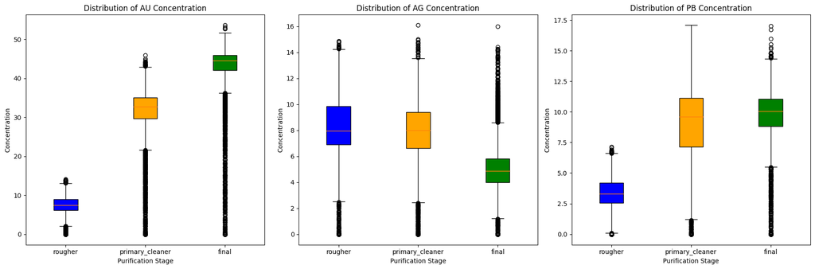

```python
# Data Visualization

colors = ['blue', 'orange', 'green', 'red']

# Boxplots

plt.figure(figsize=(18, 6))
for idx, metal in enumerate(metals):
    plt.subplot(1, 3, idx + 1)
    data = []
    labels = []
    for stage in stages:
        column = f'{stage}.output.concentrate_{metal}'
        if stage == 'rougher':
            column = f'{stage}.input.feed_{metal}'
        if column in train_data.columns:
            data.append(train_data[column].dropna())
            labels.append(stage)
    box = plt.boxplot(data, labels=labels, patch_artist=True)
    for patch, color in zip(box['boxes'], colors):
        patch.set_facecolor(color)
    plt.title(f'Distribution of {metal.upper()} Concentration')
    plt.xlabel('Purification Stage')
    plt.ylabel('Concentration')

plt.tight_layout()
plt.show()
```

**Reviewer's comment**

1. The code fell
2. Actually this is not the best suitable graph type. When you need to compare distibutions, you can use only histograms or boxplots.
3. It's better to plot 3 graphs here. One for each metal. And on each graph you should plot 4 histograms with different colors or 4 boxplots with the proper order.

**Reviewer's comment V2**

Well done!

```python
# Calculate and print the percentage change between stages

for metal in metals:
    print(f"\nPercentage change in {metal.upper()} concentration:")
    for i in range(1, len(stages)):
        if concentration_data[metal][i-1] is not None and concentration_data[metal][i] is not None:
            change = (concentration_data[metal][i] - concentration_data[metal][i-1]) / concentration_data[metal][i-1] * 100
            print(f"{stages[i-1]} to {stages[i]}: {change:.2f}%")
```

```
Percentage change in AU concentration:
rougher to primary_cleaner: 306.72%
primary_cleaner to secondary_cleaner: nan%
secondary_cleaner to final: nan%

Percentage change in AG concentration:
rougher to primary_cleaner: -5.23%
primary_cleaner to secondary_cleaner: nan%
secondary_cleaner to final: nan%

Percentage change in PB concentration:
rougher to primary_cleaner: 167.80%
primary_cleaner to secondary_cleaner: nan%
secondary_cleaner to final: nan%
```

```python
# 2.2

# Identify the feed size column
feed_size_column = 'rougher.input.feed_size'

# Extract feed size data
train_feed_size = train_data[feed_size_column].dropna()
test_feed_size = test_data[feed_size_column].dropna()
```

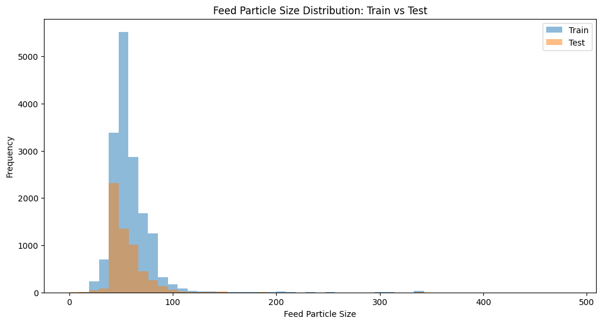

```python
# Data Visualization

plt.figure(figsize=(12, 6))
plt.hist(train_feed_size, bins=50, alpha=0.5, label='Train')
plt.hist(test_feed_size, bins=50, alpha=0.5, label='Test')
plt.xlabel('Feed Particle Size')
plt.ylabel('Frequency')
plt.title('Feed Particle Size Distribution: Train vs Test')
plt.legend()
plt.show()
```

The training and test datasets' feed particle size distributions are comparable but not the same. The closeness of the peaks and skewness is advantageous for training the model. Variations near the tails imply that in order to maintain stable model performance, outliers and uncommon values must be handled carefully. Between the training and test datasets, there is a substantial overlap in the particle size range of about 20 to 100.

**Reviewer's comment**

Well done here:)

```python
# Statistics for Train and Test datasets

train_stats = train_feed_size.describe()
test_stats = test_feed_size.describe()

print("Train Feed Size Statistics:")
print(train_stats)
print("\nTest Feed Size Statistics:")
print(test_stats)
```

```
Train Feed Size Statistics:
count    16443.000000
mean        58.676444
std         23.922591
min          9.659576
25%         47.575879
50%         54.104257
75%         65.051064
max        484.967466
Name: rougher.input.feed_size, dtype: float64

Test Feed Size Statistics:
count    5834.000000
mean       55.937535
std        22.724254
min         0.046369
25%        43.890852
50%        50.002004
75%        61.638434
max       477.445473
Name: rougher.input.feed_size, dtype: float64
```

```python
# Perform Kolmogorov-Smirnov test

ks_statistic, p_value = stats.ks_2samp(train_feed_size, test_feed_size)

print(f"\nKolmogorov-Smirnov Test:")
print(f"KS Statistic: {ks_statistic}")
print(f"p-value: {p_value}")
```

```
Kolmogorov-Smirnov Test:
KS Statistic: 0.19231080760994584
p-value: 5.871332318176002e-140
```

```python
# Interpret the results

alpha = 0.05  # significance level
if p_value < alpha:
    print("\nThe distributions are significantly different.")
    print("This may lead to incorrect model evaluation.")
else:
    print("\nThere is no significant difference between the distributions.")
    print("The model evaluation should be reliable.")
```

```
The distributions are significantly different.
This may lead to incorrect model evaluation.
```

**Reviewer's comment**

Yeah, stat. test shows that the distributions are not the same. But for ML model it's okay. They have to be just similar and that's enough.

```python
# Percentage difference in Means

mean_diff_percent = ((test_stats['mean'] - train_stats['mean']) / train_stats['mean']) * 100

print(f"\nPercentage difference in means: {mean_diff_percent:.2f}%")
```

```
Percentage difference in means: -4.67%
```

```python
# 2.3

# Merge Train and Test datasets

all_data = pd.concat([train_data, test_data], axis=0, ignore_index=True)
```

```python
# Function to calculate total concentration

def calculate_total_concentration(data, stage):
    if stage == 'raw_feed':
        columns = [col for col in data.columns if 'rougher.input.feed' in col and col.split('.')[-1] != 'size']
    elif stage == 'rougher_concentrate':
        columns = [col for col in data.columns if 'rougher.output.concentrate' in col]
    elif stage == 'final_concentrate':
        columns = [col for col in data.columns if 'final.output.concentrate' in col]
    return data[columns].sum(axis=1)

stages = ['raw_feed', 'rougher_concentrate', 'final_concentrate']
for stage in stages:
    all_data[f'total_concentration_{stage}'] = calculate_total_concentration(all_data, stage)
```

```python
# For Each Stage

thresholds = {
    'raw_feed': 10,
    'rougher_concentrate': 5,
    'final_concentrate': 1
}
```

```python
# Remove rows with concentrations below thresholds

for stage in stages:
    all_data = all_data[all_data[f'total_concentration_{stage}'] > thresholds[stage]]

print(f"{len(all_data)}")
```

```
14629
```

Rows in dataset after removing low concentrations

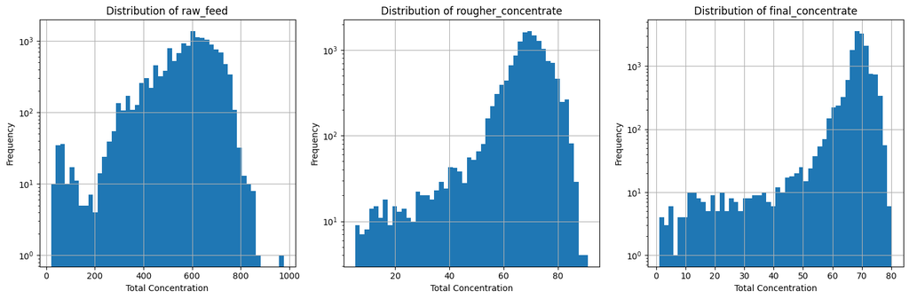

```python
# Data Visualization

plt.figure(figsize=(15, 5))
for i, stage in enumerate(stages, 1):
    plt.subplot(1, 3, i)
    all_data[f'total_concentration_{stage}'].hist(bins=50)
    plt.title(f'Distribution of {stage}')
    plt.xlabel('Total Concentration')
    plt.ylabel('Frequency')
    plt.yscale('log')
plt.tight_layout()
plt.show()
```

```python
# Print minimum values for each stage
for stage in stages:
    min_value = all_data[f'total_concentration_{stage}'].min()
    print(f"Minimum total concentration for {stage}: {min_value}")
```

```
Minimum total concentration for raw_feed: 19.466919966210458
Minimum total concentration for rougher_concentrate: 5.228249463040852
Minimum total concentration for final_concentrate: 1.0727813679777156
```

This proves that the total concentration is not zero at any of these stages.